# Assignment - Exploratory data analysis (EDA)-Prior application

```python
#### Importing all the necessary libraries
import pandas as pd
import numpy as np
import matplotlib.pyplot as plt
%matplotlib inline
import seaborn as sns
import warnings
warnings.filterwarnings("ignore")
```

```python
### Lets import the application data into pandas dataframe
p_app = pd.read_csv("previous_application.csv")
p_app.head()
```

|  | SK_ID_PREV | SK_ID_CURR | NAME_CONTRACT_TYPE | AMT_ANNUITY | AMT_APPLICATION | AMT_CREDIT | AMT_DOWN_PAYMENT | AMT_GOODS_PRICE | WEEKDAY_APPR_PROCESS_START | HOUR_APPR_PROCESS_START | ... | NAME_SELLER_INDUSTRY | CNT_PAYMENT | NAME_YIELD_GROUP | PRODUCT_COMBINATION | DAYS_FIRST_DRAWING | DAYS_FIRST_DUE | DAYS_LAST_DUE_1ST_VERSION | DAYS_LAST_DUE | DAYS_TERMINATION | NFLAG_INSURED_ON_APPROVAL |
| --- | --- | --- | --- | --- | --- | --- | --- | --- | --- | --- | --- | --- | --- | --- | --- | --- | --- | --- | --- | --- | --- |
| 0 | 2030495 | 271877 | Consumer loans | 1730.430 | 17145.0 | 17145.0 | 0.0 | 17145.0 | SATURDAY | 15 | ... | Connectivity | 12.0 | middle | POS mobile with interest | 365243.0 | -42.0 | 300.0 | -42.0 | -37.0 | 0.0 |
| 1 | 2802425 | 108129 | Cash loans | 25188.615 | 607500.0 | 679671.0 | NaN | 607500.0 | THURSDAY | 11 | ... | XNA | 36.0 | low_action | Cash X-Sell: low | 365243.0 | -134.0 | 916.0 | 365243.0 | 365243.0 | 1.0 |
| 2 | 2523466 | 122040 | Cash loans | 15060.735 | 112500.0 | 136444.5 | NaN | 112500.0 | TUESDAY | 11 | ... | XNA | 12.0 | high | Cash X-Sell: high | 365243.0 | -271.0 | 59.0 | 365243.0 | 365243.0 | 1.0 |
| 3 | 2819243 | 176158 | Cash loans | 47041.335 | 450000.0 | 470790.0 | NaN | 450000.0 | MONDAY | 7 | ... | XNA | 12.0 | middle | Cash X-Sell: middle | 365243.0 | -482.0 | -152.0 | -182.0 | -177.0 | 1.0 |
| 4 | 1784265 | 202054 | Cash loans | 31924.395 | 337500.0 | 404055.0 | NaN | 337500.0 | THURSDAY | 9 | ... | XNA | 24.0 | high | Cash Street: high | NaN | NaN | NaN | NaN | NaN | NaN |

5 rows × 37 columns

```python
p_app.columns
```

```
Index(['SK_ID_PREV', 'SK_ID_CURR', 'NAME_CONTRACT_TYPE', 'AMT_ANNUITY',
       'AMT_APPLICATION', 'AMT_CREDIT', 'AMT_DOWN_PAYMENT', 'AMT_GOODS_PRICE',
       'WEEKDAY_APPR_PROCESS_START', 'HOUR_APPR_PROCESS_START',
       'FLAG_LAST_APPL_PER_CONTRACT', 'NFLAG_LAST_APPL_IN_DAY',
       'RATE_DOWN_PAYMENT', 'RATE_INTEREST_PRIMARY',
       'RATE_INTEREST_PRIVILEGED', 'NAME_CASH_LOAN_PURPOSE',
       'NAME_CONTRACT_STATUS', 'DAYS_DECISION', 'NAME_PAYMENT_TYPE',
       'CODE_REJECT_REASON', 'NAME_TYPE_SUITE', 'NAME_CLIENT_TYPE',
       'NAME_GOODS_CATEGORY', 'NAME_PORTFOLIO', 'NAME_PRODUCT_TYPE',
       'CHANNEL_TYPE', 'SELLERPLACE_AREA', 'NAME_SELLER_INDUSTRY',
       'CNT_PAYMENT', 'NAME_YIELD_GROUP', 'PRODUCT_COMBINATION',
       'DAYS_FIRST_DRAWING', 'DAYS_FIRST_DUE', 'DAYS_LAST_DUE_1ST_VERSION',
       'DAYS_LAST_DUE', 'DAYS_TERMINATION', 'NFLAG_INSURED_ON_APPROVAL'],
      dtype='object')
```

```python
### As we are unable to check on all the rows and columns, we will change the settings in pandas
pd.set_option('display.max_columns', 400)
pd.set_option('display.max_rows', 400)
```

```python
p_app.info()
```

```
<class 'pandas.core.frame.DataFrame'>
RangeIndex: 1670214 entries, 0 to 1670213
Data columns (total 37 columns):
SK_ID_PREV                     1670214 non-null int64
SK_ID_CURR                     1670214 non-null int64
NAME_CONTRACT_TYPE             1670214 non-null object
AMT_ANNUITY                    1297979 non-null float64
AMT_APPLICATION                1670214 non-null float64
AMT_CREDIT                     1670213 non-null float64
AMT_DOWN_PAYMENT               774370 non-null float64
AMT_GOODS_PRICE                1284699 non-null float64
WEEKDAY_APPR_PROCESS_START     1670214 non-null object
HOUR_APPR_PROCESS_START        1670214 non-null int64
FLAG_LAST_APPL_PER_CONTRACT    1670214 non-null object
NFLAG_LAST_APPL_IN_DAY         1670214 non-null int64
RATE_DOWN_PAYMENT              774370 non-null float64
RATE_INTEREST_PRIMARY          5951 non-null float64
RATE_INTEREST_PRIVILEGED       5951 non-null float64
NAME_CASH_LOAN_PURPOSE         1670214 non-null object
NAME_CONTRACT_STATUS           1670214 non-null object
DAYS_DECISION                  1670214 non-null int64
NAME_PAYMENT_TYPE              1670214 non-null object
CODE_REJECT_REASON             1670214 non-null object
NAME_TYPE_SUITE                849809 non-null object
NAME_CLIENT_TYPE               1670214 non-null object
NAME_GOODS_CATEGORY            1670214 non-null object
NAME_PORTFOLIO                 1670214 non-null object
NAME_PRODUCT_TYPE              1670214 non-null object
CHANNEL_TYPE                   1670214 non-null object
SELLERPLACE_AREA               1670214 non-null int64
NAME_SELLER_INDUSTRY           1670214 non-null object
CNT_PAYMENT                    1297984 non-null float64
NAME_YIELD_GROUP               1670214 non-null object
PRODUCT_COMBINATION            1669868 non-null object
DAYS_FIRST_DRAWING             997149 non-null float64
DAYS_FIRST_DUE                 997149 non-null float64
DAYS_LAST_DUE_1ST_VERSION      997149 non-null float64
DAYS_LAST_DUE                  997149 non-null float64
DAYS_TERMINATION               997149 non-null float64
NFLAG_INSURED_ON_APPROVAL      997149 non-null float64
dtypes: float64(15), int64(6), object(16)
memory usage: 471.5+ MB
```

```python
p_app["CODE_REJECT_REASON"].value_counts()
```

```
XAP       1353093
HC         175231
LIMIT       55680
SCO         37467
CLIENT      26436
SCOFR       12811
XNA          5244
VERIF        3535
SYSTEM        717
Name: CODE_REJECT_REASON, dtype: int64
```

```python
num_lis = list(p_app.select_dtypes(["float64"]).columns)
num_lis
```

```
['AMT_ANNUITY',
 'AMT_APPLICATION',
 'AMT_CREDIT',
 'AMT_DOWN_PAYMENT',
 'AMT_GOODS_PRICE',
 'RATE_DOWN_PAYMENT',
 'RATE_INTEREST_PRIMARY',
 'RATE_INTEREST_PRIVILEGED',
 'CNT_PAYMENT',
 'DAYS_FIRST_DRAWING',
 'DAYS_FIRST_DUE',
 'DAYS_LAST_DUE_1ST_VERSION',
 'DAYS_LAST_DUE',
 'DAYS_TERMINATION',
 'NFLAG_INSURED_ON_APPROVAL']
```

```python
obj_lis = list(p_app.select_dtypes(["object"]).columns)
obj_lis
```

```
['NAME_CONTRACT_TYPE',
 'WEEKDAY_APPR_PROCESS_START',
 'FLAG_LAST_APPL_PER_CONTRACT',
 'NAME_CASH_LOAN_PURPOSE',
 'NAME_CONTRACT_STATUS',
 'NAME_PAYMENT_TYPE',
 'CODE_REJECT_REASON',
 'NAME_TYPE_SUITE',
 'NAME_CLIENT_TYPE',
 'NAME_GOODS_CATEGORY',
 'NAME_PORTFOLIO',
 'NAME_PRODUCT_TYPE',
 'CHANNEL_TYPE',
 'NAME_SELLER_INDUSTRY',
 'NAME_YIELD_GROUP',
 'PRODUCT_COMBINATION']
```

```python
### Checking on missing entries with prior data
p_app.isna().sum()/len(p_app)*100
```

```
SK_ID_PREV                      0.000000
SK_ID_CURR                      0.000000
NAME_CONTRACT_TYPE              0.000000
AMT_ANNUITY                    22.286665
AMT_APPLICATION                 0.000000
AMT_CREDIT                      0.000060
AMT_DOWN_PAYMENT               53.636480
AMT_GOODS_PRICE                23.081773
WEEKDAY_APPR_PROCESS_START      0.000000
HOUR_APPR_PROCESS_START         0.000000
FLAG_LAST_APPL_PER_CONTRACT     0.000000
NFLAG_LAST_APPL_IN_DAY          0.000000
RATE_DOWN_PAYMENT              53.636480
RATE_INTEREST_PRIMARY          99.643698
RATE_INTEREST_PRIVILEGED       99.643698
NAME_CASH_LOAN_PURPOSE          0.000000
NAME_CONTRACT_STATUS            0.000000
DAYS_DECISION                   0.000000
NAME_PAYMENT_TYPE               0.000000
CODE_REJECT_REASON              0.000000
NAME_TYPE_SUITE                49.119754
NAME_CLIENT_TYPE                0.000000
NAME_GOODS_CATEGORY             0.000000
NAME_PORTFOLIO                  0.000000
NAME_PRODUCT_TYPE               0.000000
CHANNEL_TYPE                    0.000000
SELLERPLACE_AREA                0.000000
NAME_SELLER_INDUSTRY            0.000000
CNT_PAYMENT                    22.286366
NAME_YIELD_GROUP                0.000000
PRODUCT_COMBINATION             0.020716
DAYS_FIRST_DRAWING             40.298129
DAYS_FIRST_DUE                 40.298129
DAYS_LAST_DUE_1ST_VERSION      40.298129
DAYS_LAST_DUE                  40.298129
DAYS_TERMINATION               40.298129
NFLAG_INSURED_ON_APPROVAL      40.298129
dtype: float64
```

```python
obj_lis
```

```
['NAME_CONTRACT_TYPE',
 'WEEKDAY_APPR_PROCESS_START',
 'FLAG_LAST_APPL_PER_CONTRACT',
 'NAME_CASH_LOAN_PURPOSE',
 'NAME_CONTRACT_STATUS',
 'NAME_PAYMENT_TYPE',
 'CODE_REJECT_REASON',
 'NAME_TYPE_SUITE',
 'NAME_CLIENT_TYPE',
 'NAME_GOODS_CATEGORY',
 'NAME_PORTFOLIO',
 'NAME_PRODUCT_TYPE',
 'CHANNEL_TYPE',
 'NAME_SELLER_INDUSTRY',
 'NAME_YIELD_GROUP',
 'PRODUCT_COMBINATION']
```

```python
p_app.NAME_CONTRACT_TYPE.value_counts(normalize = True)
```

```
Cash loans         0.447579
Consumer loans     0.436561
Revolving loans    0.115652
XNA                0.000207
Name: NAME_CONTRACT_TYPE, dtype: float64
```

```python
p_app.WEEKDAY_APPR_PROCESS_START.value_counts(normalize = True)
```

```
TUESDAY      0.152746
WEDNESDAY    0.152681
MONDAY       0.151811
FRIDAY       0.150908
THURSDAY     0.149142
SATURDAY     0.144072
SUNDAY       0.098641
Name: WEEKDAY_APPR_PROCESS_START, dtype: float64
```

```
Cash loans         0.447579
Consumer loans     0.436561
Revolving loans    0.115652
XNA                0.000207
Name: NAME_CONTRACT_TYPE, dtype: float64
```

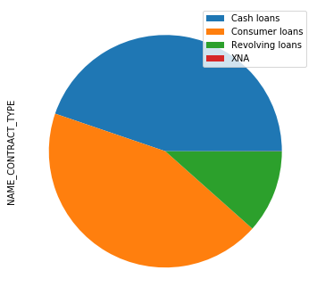

```
TUESDAY      0.152746
WEDNESDAY    0.152681
MONDAY       0.151811
FRIDAY       0.150908
THURSDAY     0.149142
SATURDAY     0.144072
SUNDAY       0.098641
Name: WEEKDAY_APPR_PROCESS_START, dtype: float64
```

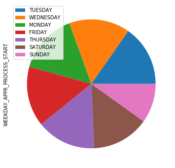

```
Y    0.994926
N    0.005074
Name: FLAG_LAST_APPL_PER_CONTRACT, dtype: float64
```

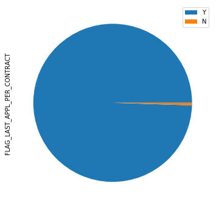

```
XAP                                 0.552421
XNA                                 0.405887
Repairs                             0.014229
Other                               0.009345
Urgent needs                        0.005036
Buying a used car                   0.001729
Building a house or an annex        0.001612
Everyday expenses                   0.001447
Medicine                            0.001302
Payments on other loans             0.001156
Education                           0.000942
Journey                             0.000742
Purchase of electronic equipment    0.000635
Buying a new car                    0.000606
Wedding / gift / holiday            0.000576
Buying a home                       0.000518
Car repairs                         0.000477
Furniture                           0.000448
Buying a holiday home / land        0.000319
Business development                0.000255
Gasification / water supply         0.000180
Buying a garage                     0.000081
Hobby                               0.000033
Money for a third person            0.000015
Refusal to name the goal            0.000009
Name: NAME_CASH_LOAN_PURPOSE, dtype: float64
```

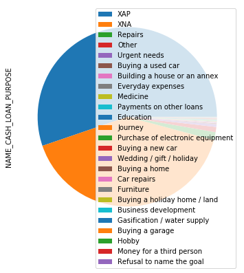

```
Approved        0.620747
Canceled        0.189388
Refused         0.174036
Unused offer    0.015828
Name: NAME_CONTRACT_STATUS, dtype: float64
```

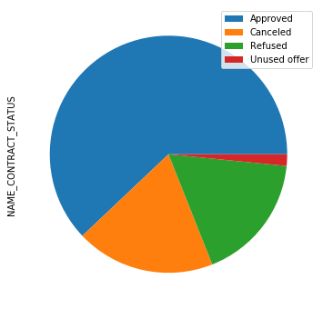

```
Cash through the bank                        0.618814
XNA                                          0.375631
Non-cash from your account                   0.004905
Cashless from the account of the employer    0.000650
Name: NAME_PAYMENT_TYPE, dtype: float64
```

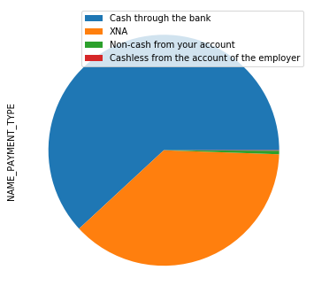

```
XAP       0.810132
HC        0.104915
LIMIT     0.033337
SCO       0.022432
CLIENT    0.015828
SCOFR     0.007670
XNA       0.003140
VERIF     0.002116
SYSTEM    0.000429
Name: CODE_REJECT_REASON, dtype: float64
```

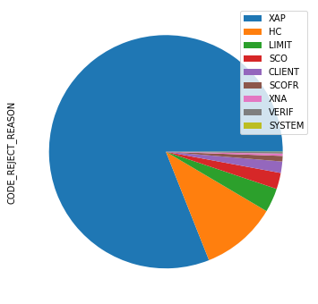

```
NaN                0.491198
Unaccompanied      0.304733
Family             0.127686
Spouse, partner    0.040156
Children           0.018899
Other_B            0.010552
Other_A            0.005435
Group of people    0.001341
Name: NAME_TYPE_SUITE, dtype: float64
```

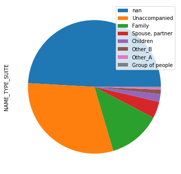

```
Repeater     0.737188
New          0.180434
Refreshed    0.081217
XNA          0.001162
Name: NAME_CLIENT_TYPE, dtype: float64
```

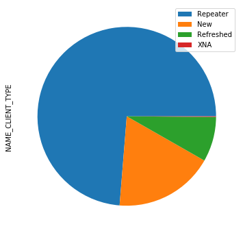

```
XNA                         5.692738e-01
Mobile                      1.345384e-01
Consumer Electronics        7.279067e-02
Computers                   6.332662e-02
Audio/Video                 5.953788e-02
Furniture                   3.212522e-02
Photo / Cinema Equipment    1.498072e-02
Construction Materials      1.496515e-02
Clothing and Accessories    1.410238e-02
Auto Accessories            4.419194e-03
Jewelry                     3.765984e-03
Homewares                   3.007399e-03
Medical Supplies            2.300903e-03
Vehicles                    2.017706e-03
Sport and Leisure           1.784801e-03
Gardening                   1.597400e-03
Other                       1.529145e-03
Office Appliances           1.396827e-03
Tourism                     9.932859e-04
Medicine                    9.280248e-04
Direct Sales                2.670316e-04
Fitness                     1.251337e-04
Additional Service          7.663689e-05
Education                   6.406365e-05
Weapon                      4.610188e-05
Insurance                   3.831844e-05
House Construction          5.987257e-07
Animals                     5.987257e-07
Name: NAME_GOODS_CATEGORY, dtype: float64
```

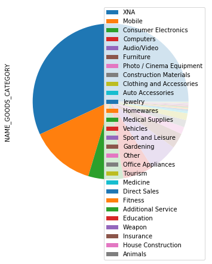

```
POS      0.413726
Cash     0.276350
XNA      0.222864
Cards    0.086806
Cars     0.000254
Name: NAME_PORTFOLIO, dtype: float64
```

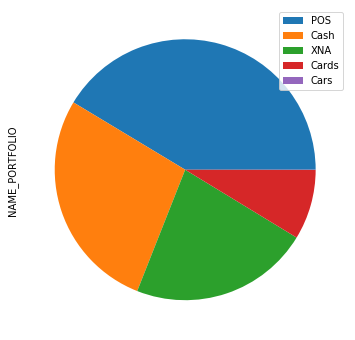

```
XNA        0.636844
x-sell     0.273191
walk-in    0.089965
Name: NAME_PRODUCT_TYPE, dtype: float64
```

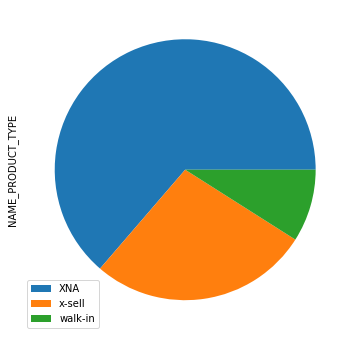

```
Credit and cash offices       0.431063
Country-wide                  0.296184
Stone                         0.126980
Regional / Local              0.064978
Contact center                0.042687
AP+ (Cash loan)               0.034155
Channel of corporate sales    0.003682
Car dealer                    0.000271
Name: CHANNEL_TYPE, dtype: float64
```

[4 more figures not shown]

```python
#Checking object types Variables and their values
for i in p_app.columns:
    if p_app[i].dtypes=="object":
        print(p_app[i].value_counts(normalize=True, dropna= False))
        plt.figure(figsize=[6,6])
        p_app[i].value_counts(normalize=True, dropna=False).plot.pie(labeldistance=None)
        plt.legend()
        plt.show()
        print("\n")
```

#### Observations

- New type of loan, Consumer Loan, which was not there in Application data frame. 43% of loans are consumer loans. 44% cash loans and rest revolving/XNA
- Approved loans are 62% and refused, cancelled, unused - rest
- 73% are repeaters.
- 41% of the applicants have taken loan for POS purchase.
- Name seller industry has 51% XNA values, Consumer electronics is next highest category at 23%

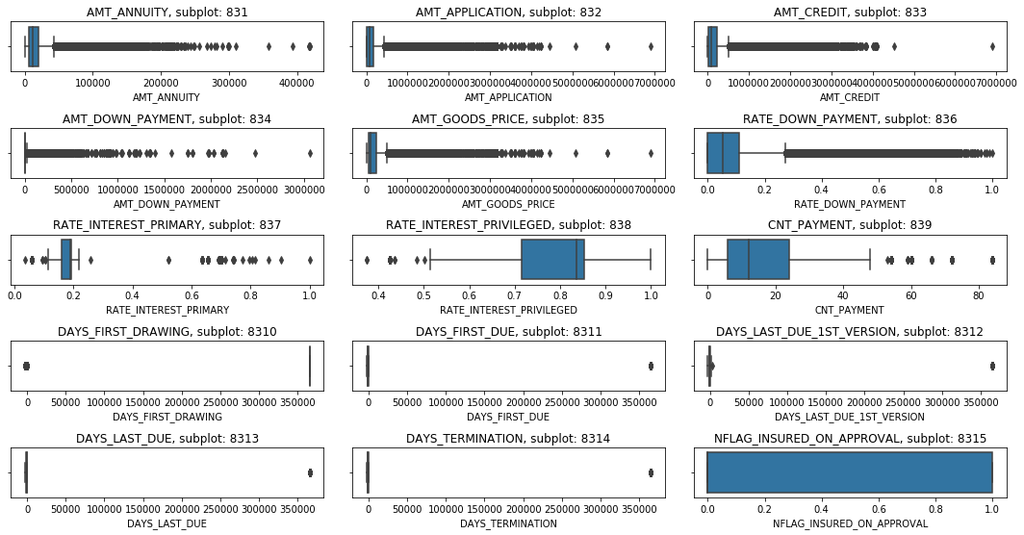

```python
#  Continous data
a = 8  # number of rows
b = 3  # number of columns
c = 1  # initialize plot counter

fig = plt.figure(figsize=(15,12))

for i in p_app.columns:
    if p_app[i].dtypes=="float64" or p_app[i].dtypes=="float32" :
        plt.subplot(a, b, c)
        plt.title('{}, subplot: {}{}{}'.format(i, a, b, c))
        plt.xlabel(i)
        sns.boxplot(p_app[i])
        c = c + 1

fig.tight_layout()
plt.show();
```

#### High level outliers in continous data

##### Now we can focus on the dataset for the reason of loans not approved for that , we take only entries of data where the loans are not approved

```python
unapprov_data = p_app[p_app["NAME_CONTRACT_STATUS"] != "Approved"]
```

```python
unapprov_data.head()
```

|  | SK_ID_PREV | SK_ID_CURR | NAME_CONTRACT_TYPE | AMT_ANNUITY | AMT_APPLICATION | AMT_CREDIT | AMT_DOWN_PAYMENT | AMT_GOODS_PRICE | WEEKDAY_APPR_PROCESS_START | HOUR_APPR_PROCESS_START | FLAG_LAST_APPL_PER_CONTRACT | NFLAG_LAST_APPL_IN_DAY | RATE_DOWN_PAYMENT | RATE_INTEREST_PRIMARY | RATE_INTEREST_PRIVILEGED | NAME_CASH_LOAN_PURPOSE | NAME_CONTRACT_STATUS | DAYS_DECISION | NAME_PAYMENT_TYPE | CODE_REJECT_REASON | NAME_TYPE_SUITE | NAME_CLIENT_TYPE | NAME_GOODS_CATEGORY | NAME_PORTFOLIO | NAME_PRODUCT_TYPE | CHANNEL_TYPE | SELLERPLACE_AREA | NAME_SELLER_INDUSTRY | CNT_PAYMENT | … |
| --- | --- | --- | --- | --- | --- | --- | --- | --- | --- | --- | --- | --- | --- | --- | --- | --- | --- | --- | --- | --- | --- | --- | --- | --- | --- | --- | --- | --- | --- | --- |
| 4 | 1784265 | 202054 | Cash loans | 31924.395 | 337500.0 | 404055.0 | NaN | 337500.0 | THURSDAY | 9 | Y | 1 | NaN | NaN | NaN | Repairs | Refused | -781 | Cash through the bank | HC | NaN | Repeater | XNA | Cash | walk-in | Credit and cash offices | -1 | XNA | 24.0 | … |
| 6 | 2315218 | 175704 | Cash loans | NaN | 0.0 | 0.0 | NaN | NaN | TUESDAY | 11 | Y | 1 | NaN | NaN | NaN | XNA | Canceled | -14 | XNA | XAP | NaN | Repeater | XNA | XNA | XNA | Credit and cash offices | -1 | XNA | NaN | … |
| 7 | 1656711 | 296299 | Cash loans | NaN | 0.0 | 0.0 | NaN | NaN | MONDAY | 7 | Y | 1 | NaN | NaN | NaN | XNA | Canceled | -21 | XNA | XAP | NaN | Repeater | XNA | XNA | XNA | Credit and cash offices | -1 | XNA | NaN | … |
| 8 | 2367563 | 342292 | Cash loans | NaN | 0.0 | 0.0 | NaN | NaN | MONDAY | 15 | Y | 1 | NaN | NaN | NaN | XNA | Canceled | -386 | XNA | XAP | NaN | Repeater | XNA | XNA | XNA | Credit and cash offices | -1 | XNA | NaN | … |
| 9 | 2579447 | 334349 | Cash loans | NaN | 0.0 | 0.0 | NaN | NaN | SATURDAY | 15 | Y | 1 | NaN | NaN | NaN | XNA | Canceled | -57 | XNA | XAP | NaN | Repeater | XNA | XNA | XNA | Credit and cash offices | -1 | XNA | NaN | … |

```
Cash loans         0.686755
Consumer loans     0.162102
Revolving loans    0.150597
XNA                0.000546
Name: NAME_CONTRACT_TYPE, dtype: float64
```

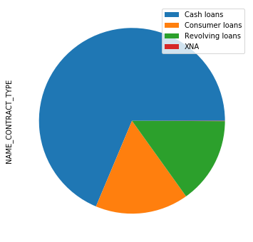

```
MONDAY       0.164134
TUESDAY      0.163940
WEDNESDAY    0.162453
THURSDAY     0.157420
FRIDAY       0.156184
SATURDAY     0.122567
SUNDAY       0.073302
Name: WEEKDAY_APPR_PROCESS_START, dtype: float64
```

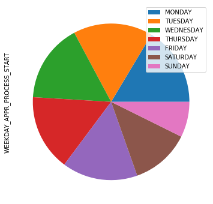

```
Y    0.986621
N    0.013379
Name: FLAG_LAST_APPL_PER_CONTRACT, dtype: float64
```

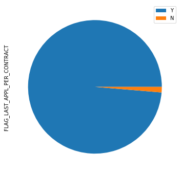

```
XNA                                 0.619341
XAP                                 0.313245
Repairs                             0.023819
Other                               0.014099
Urgent needs                        0.007638
Building a house or an annex        0.003186
Buying a used car                   0.003168
Payments on other loans             0.002569
Everyday expenses                   0.001863
Medicine                            0.001795
Education                           0.001276
Buying a new car                    0.001249
Journey                             0.001074
Buying a home                       0.001050
Wedding / gift / holiday            0.000892
Purchase of electronic equipment    0.000747
Car repairs                         0.000693
Furniture                           0.000657
Buying a holiday home / land        0.000633
Business development                0.000467
Gasification / water supply         0.000292
Buying a garage                     0.000153
Hobby                               0.000057
Money for a third person            0.000021
Refusal to name the goal            0.000017
Name: NAME_CASH_LOAN_PURPOSE, dtype: float64
```

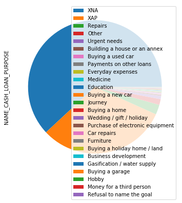

```
Canceled        0.499372
Refused         0.458893
Unused offer    0.041734
Name: NAME_CONTRACT_STATUS, dtype: float64
```

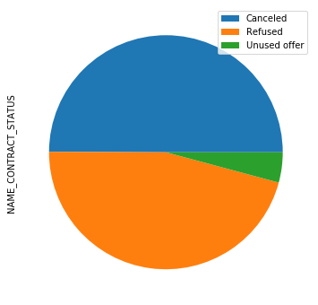

```
XNA                                          0.656071
Cash through the bank                        0.341596
Non-cash from your account                   0.001981
Cashless from the account of the employer    0.000352
Name: NAME_PAYMENT_TYPE, dtype: float64
```

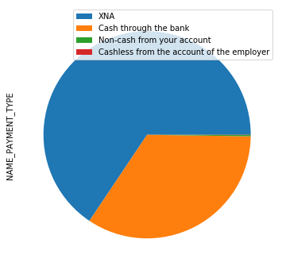

```
XAP       0.499374
HC        0.276637
LIMIT     0.087902
SCO       0.059149
CLIENT    0.041734
SCOFR     0.020225
XNA       0.008266
VERIF     0.005581
SYSTEM    0.001132
Name: CODE_REJECT_REASON, dtype: float64
```

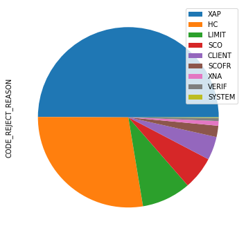

```
NaN                0.707196
Unaccompanied      0.207078
Family             0.055133
Spouse, partner    0.015635
Children           0.007084
Other_B            0.004667
Other_A            0.002395
Group of people    0.000813
Name: NAME_TYPE_SUITE, dtype: float64
```

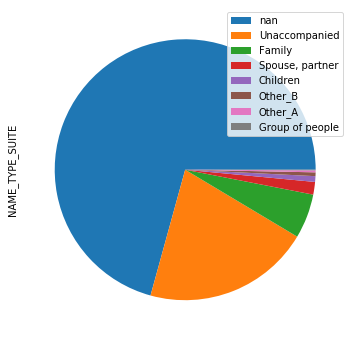

```
Repeater     0.905253
Refreshed    0.060857
New          0.031738
XNA          0.002152
Name: NAME_CLIENT_TYPE, dtype: float64
```

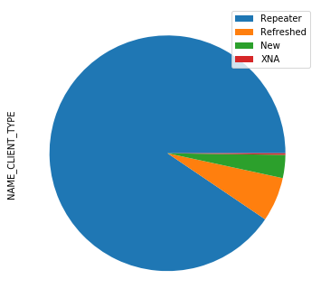

```
XNA                         0.853127
Mobile                      0.060834
Computers                   0.027973
Consumer Electronics        0.015868
Audio/Video                 0.015861
Furniture                   0.007208
Photo / Cinema Equipment    0.005750
Construction Materials      0.003985
Clothing and Accessories    0.003306
Auto Accessories            0.001296
Jewelry                     0.000965
Homewares                   0.000763
Vehicles                    0.000600
Medical Supplies            0.000480
Sport and Leisure           0.000415
Office Appliances           0.000396
Gardening                   0.000314
Tourism                     0.000311
Other                       0.000193
Medicine                    0.000161
Direct Sales                0.000117
Education                   0.000025
Insurance                   0.000019
Additional Service          0.000019
Weapon                      0.000011
Fitness                     0.000003
House Construction          0.000002
Name: NAME_GOODS_CATEGORY, dtype: float64
```

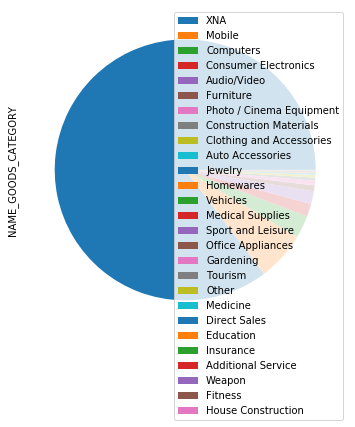

```
XNA      0.587633
Cash     0.235269
POS      0.102306
Cards    0.074537
Cars     0.000256
Name: NAME_PORTFOLIO, dtype: float64
```

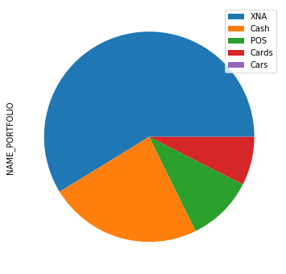

```
XNA        0.690195
x-sell     0.187294
walk-in    0.122512
Name: NAME_PRODUCT_TYPE, dtype: float64
```

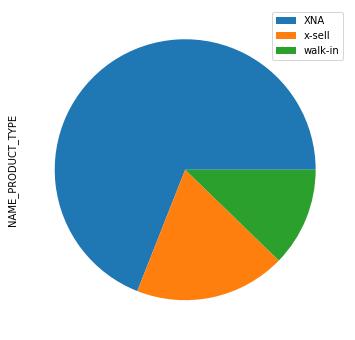

```
Credit and cash offices       0.680280
Country-wide                  0.145087
Contact center                0.072742
AP+ (Cash loan)               0.040754
Stone                         0.036228
Regional / Local              0.019120
Channel of corporate sales    0.005527
Car dealer                    0.000262
Name: CHANNEL_TYPE, dtype: float64
```

[4 more figures not shown]

```python
#Checking object types Variables and their values
for i in unapprov_data.columns:
    if unapprov_data[i].dtypes=="object":
        print(unapprov_data[i].value_counts(normalize=True, dropna= False))
        plt.figure(figsize=[6,6])
        unapprov_data[i].value_counts(normalize=True, dropna=False).plot.pie(labeldistance=None)
        plt.legend()
        plt.show()
        print("\n")
```

```python
unapprov_data.isnull().sum()
```

```
SK_ID_PREV                          0
SK_ID_CURR                          0
NAME_CONTRACT_TYPE                  0
AMT_ANNUITY                    372227
AMT_APPLICATION                     0
AMT_CREDIT                          0
AMT_DOWN_PAYMENT               521444
AMT_GOODS_PRICE                342680
WEEKDAY_APPR_PROCESS_START          0
HOUR_APPR_PROCESS_START             0
FLAG_LAST_APPL_PER_CONTRACT         0
NFLAG_LAST_APPL_IN_DAY              0
RATE_DOWN_PAYMENT              521444
RATE_INTEREST_PRIMARY          633433
RATE_INTEREST_PRIVILEGED       633433
NAME_CASH_LOAN_PURPOSE              0
NAME_CONTRACT_STATUS                0
DAYS_DECISION                       0
NAME_PAYMENT_TYPE                   0
CODE_REJECT_REASON                  0
NAME_TYPE_SUITE                447961
NAME_CLIENT_TYPE                    0
NAME_GOODS_CATEGORY                 0
NAME_PORTFOLIO                      0
NAME_PRODUCT_TYPE                   0
CHANNEL_TYPE                        0
SELLERPLACE_AREA                    0
NAME_SELLER_INDUSTRY                0
CNT_PAYMENT                    372226
NAME_YIELD_GROUP                    0
PRODUCT_COMBINATION               346
DAYS_FIRST_DRAWING             633433
DAYS_FIRST_DUE                 633433
DAYS_LAST_DUE_1ST_VERSION      633433
DAYS_LAST_DUE                  633433
DAYS_TERMINATION               633433
NFLAG_INSURED_ON_APPROVAL      633433
dtype: int64
```

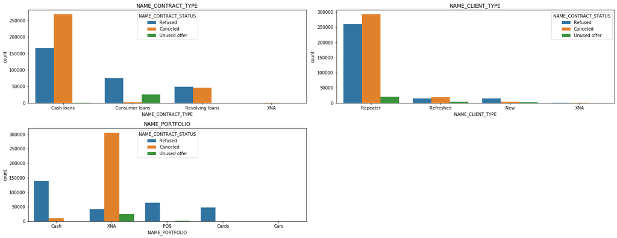

```python
cols=['NAME_CONTRACT_TYPE','NAME_CLIENT_TYPE','NAME_PORTFOLIO']


a = 4  # number of rows
b = 2  # number of columns
c = 1  # initialize plot counter

fig = plt.figure(figsize=(20,15))

for i in cols:

    plt.subplot(a, b, c)
    plt.title(i)
    plt.xlabel(i)
    sns.countplot(x=i, data=unapprov_data, hue='NAME_CONTRACT_STATUS')
    c = c + 1

fig.tight_layout()
plt.show();
```

- Most of the rejected loans have cancelled for cash loans and refused for consumer loans.
- Most of rejected applications are with loans applied by repeaters

#### Identifying top correlations for unapproved loans

```python
unapprov_data.columns
```

```
Index(['SK_ID_PREV', 'SK_ID_CURR', 'NAME_CONTRACT_TYPE', 'AMT_ANNUITY',
       'AMT_APPLICATION', 'AMT_CREDIT', 'AMT_DOWN_PAYMENT', 'AMT_GOODS_PRICE',
       'WEEKDAY_APPR_PROCESS_START', 'HOUR_APPR_PROCESS_START',
       'FLAG_LAST_APPL_PER_CONTRACT', 'NFLAG_LAST_APPL_IN_DAY',
       'RATE_DOWN_PAYMENT', 'RATE_INTEREST_PRIMARY',
       'RATE_INTEREST_PRIVILEGED', 'NAME_CASH_LOAN_PURPOSE',
       'NAME_CONTRACT_STATUS', 'DAYS_DECISION', 'NAME_PAYMENT_TYPE',
       'CODE_REJECT_REASON', 'NAME_TYPE_SUITE', 'NAME_CLIENT_TYPE',
       'NAME_GOODS_CATEGORY', 'NAME_PORTFOLIO', 'NAME_PRODUCT_TYPE',
       'CHANNEL_TYPE', 'SELLERPLACE_AREA', 'NAME_SELLER_INDUSTRY',
       'CNT_PAYMENT', 'NAME_YIELD_GROUP', 'PRODUCT_COMBINATION',
       'DAYS_FIRST_DRAWING', 'DAYS_FIRST_DUE', 'DAYS_LAST_DUE_1ST_VERSION',
       'DAYS_LAST_DUE', 'DAYS_TERMINATION', 'NFLAG_INSURED_ON_APPROVAL'],
      dtype='object')
```

```python
prior_corr= unapprov_data.drop(axis=1,columns=['SK_ID_CURR','SK_ID_PREV'] )

correlation=prior_corr.corr().abs()
####
corr_pre = correlation.where(np.triu(np.ones(correlation.shape),k=1).astype(np.bool)).unstack().reset_index()
corr_pre.columns=['Column1','Column2','Correlation']
corr_pre.dropna(subset=['Correlation'],inplace=True)
corr_pre = corr_pre.sort_values(by=['Correlation'], ascending=False)

corr_pre.head(10)
```

|  | Column1 | Column2 | Correlation |
| --- | --- | --- | --- |
| 77 | AMT_GOODS_PRICE | AMT_APPLICATION | 0.999733 |
| 78 | AMT_GOODS_PRICE | AMT_CREDIT | 0.992103 |
| 39 | AMT_CREDIT | AMT_APPLICATION | 0.988032 |
| 76 | AMT_GOODS_PRICE | AMT_ANNUITY | 0.823066 |
| 38 | AMT_CREDIT | AMT_ANNUITY | 0.820533 |
| 19 | AMT_APPLICATION | AMT_ANNUITY | 0.818846 |
| 230 | CNT_PAYMENT | AMT_CREDIT | 0.678371 |
| 229 | CNT_PAYMENT | AMT_APPLICATION | 0.670327 |
| 232 | CNT_PAYMENT | AMT_GOODS_PRICE | 0.658841 |
| 79 | AMT_GOODS_PRICE | AMT_DOWN_PAYMENT | 0.552878 |

#### Observations

- AMT_GOODS_PRICE, AMT_ANNUITY, AMT_APPLICATION have high correlation. More good purchased more the loan money.
- Similary, AMT_Credit to AMT_GOOD_PRICE also the correlation is high